# Trafford’s population estimates

## Mid-year 2024

### Trafford’s population growth was the lowest in GM

ONS has published the Mid-year 2024 population estimates and revised estimates for 2023 for England and Wales, including local authority levels.

In Mid-year 2024, the Trafford population was 241,025, which is 2,049 more than the population in Mid-year 2023.

From Mid-year 2023 to Mid-year 2024, the population has grown by 0.9%, this is 0.6% less than Greater Manchester (GM) at 1.5% growth and 0.3% less than England at 1.2% growth. Trafford has the lowest growth compared to the rest of GM authorities and the third lowest growth of 15 similar local authorities (Similar Authorities).

The median age in Trafford was 40.7 years, 0.2 years less than the median age in Mid-year 2023. Trafford had the second highest median age among GM authorities. GM’s median age is 36.9 years, and England’s median age is 40.2 years.

Considering the trend in population growth from 2011, between mid 2014 and mid 2015, the year on year growth of Trafford’s population became the second lowest among the GM authorities and from 2017 to 2018, Trafford became the lowest growing authority.

From 2022 Trafford’s population has been increasing at a lower rate than England and GM authorities.

Select the tabs below for:

#### 2023 to 2024

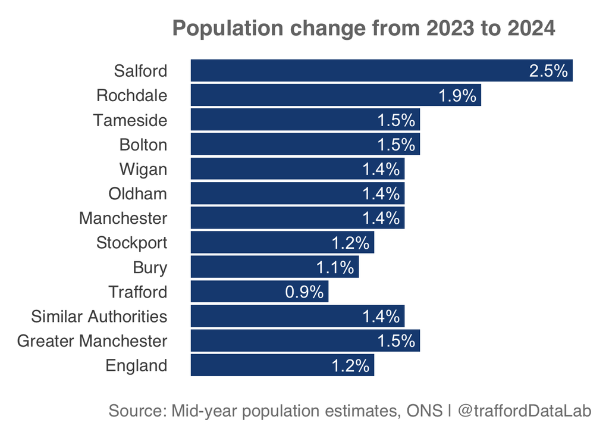

#### 2011 to 2024

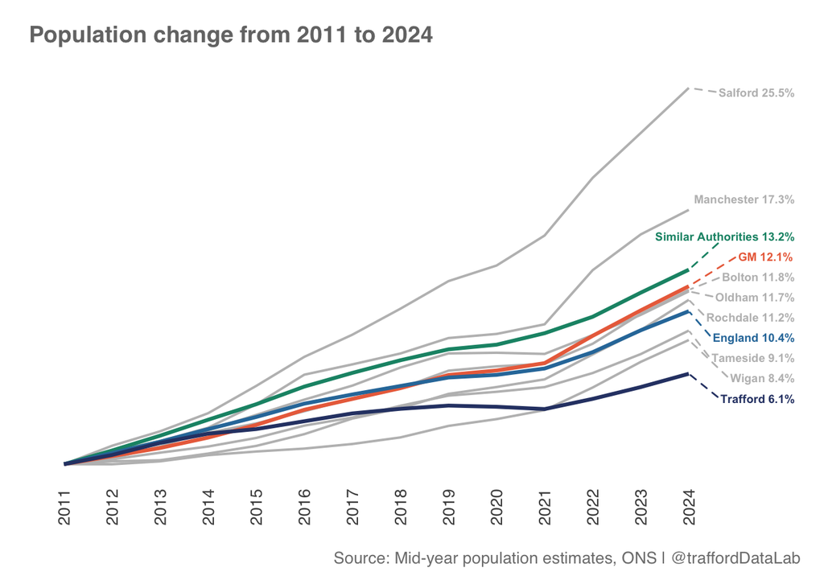

### Females and Males 25 to 29 years old had the largest increase in growth

Comparing the change from Mid-2023 to Mid-2024, 25 to 29 years olds had the largest increase in growth and number with females increasing by 5% and 324 more residents, and males increasing by 5.5% and 356 more residents.

The age group 0 to 4 had the largest decrease for both female and male, with females showing a 4.3% decline and 267 fewer females and males with a 2.4% decline and 156 fewer males.

Overall, the female population grew 0.68% whilst the male population grew 1.04%

From 2021, the under 5 years old, the 50 to 59 group and the 70 to 74 group had reduced in population. Children over 5 and the young adult population have increased as well as older adults aged over 75.

Select the tabs below for:

#### 2023 to 2024

[interactive chart not shown]

#### 2021 to 2024

[interactive chart not shown]

Select the tabs below for:

#### 2023 to 2024

[interactive chart not shown]

#### 2021 to 2024

[interactive chart not shown]

### Population under 5 is decreasing in Trafford but increasing in GM

Compared to 2024, Trafford’s under 5 population have decreased 3.3% from 2023 and 6.6% from 2021 while GM’s under 5 population have increased 0.2% from 2023 and 1.7% from 2021. England decreased 0.2% from 2023 and increased 0.4% from 2021.

Another notable difference in age group growth that is consistent both from 2023 and from 2021 is a decrease in 30 to 39 years olds whilst in GM, England and Similar authorities this age group is increasing

From 2023 to 2024 all three broad age groups grew at a similar rate of 0.8% for 0 to 17 and 65 and over, and 0.9% for 18 to 64 years groups. England’s 65 and over age group grew at a higher rate of 1.8%. GM under 64 years group grew at a higher rate compared to Trafford.

From 2021 to 2024 the 0 to 17 years population of Trafford grew at a similar rate to England, both at 3.6%, however England grew at a higher rate for other ages. Across all age groups, Greater Manchester (GM) experienced faster population growth than Trafford, especially in the 18–64 age group, which grew by 5.4%.

Select the tabs below for:

#### 2023 to 2024

[interactive chart not shown]

#### 2021 to 2024

[interactive chart not shown]

### The number of births and deaths is nearly equal.

From Mid-year 2023 to Mid-year 2024, there was an estimate of 2,153 births and 2,098 deaths, with a surplus of births over deaths of 55 bringing natural change to positive numbers after becoming negative in 2023.

The Internal Migration inflow was 14,879 and the Internal Migration outflow was 14,823, with a positive net Internal Migration of 56 after several years of negative numbers starting from 2019.

The International Migration inflow was 3,045 and the International Migration outflow was 1,115, with a net international migration of 1,930. Net International migration is the largest component of population growth for the third year for Trafford, all GM authorities, and England, although it reduced from last year. Other changes account for 8 additional residents.

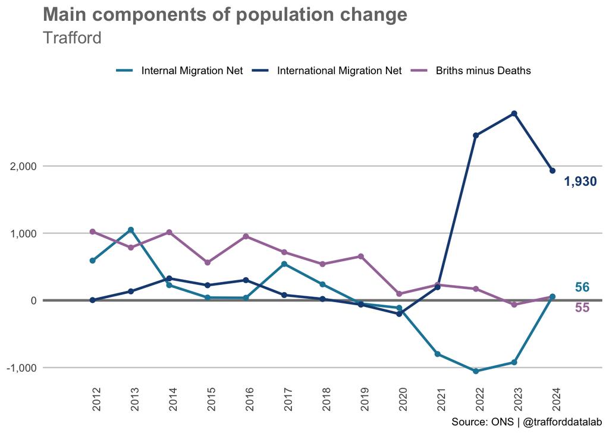

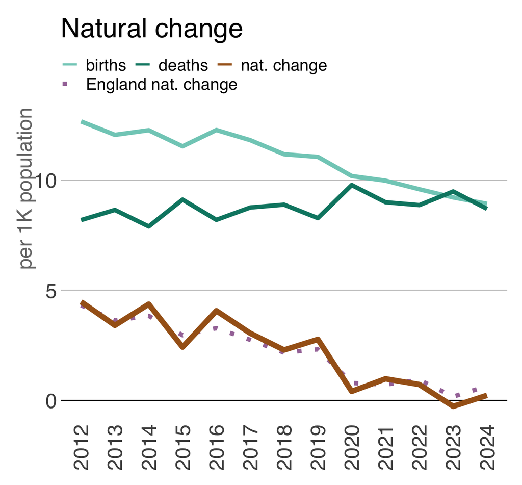

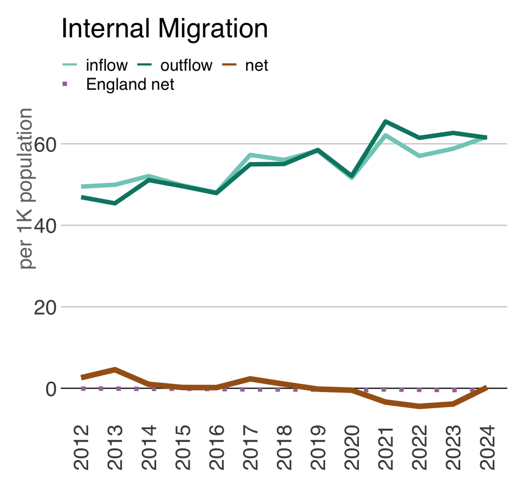

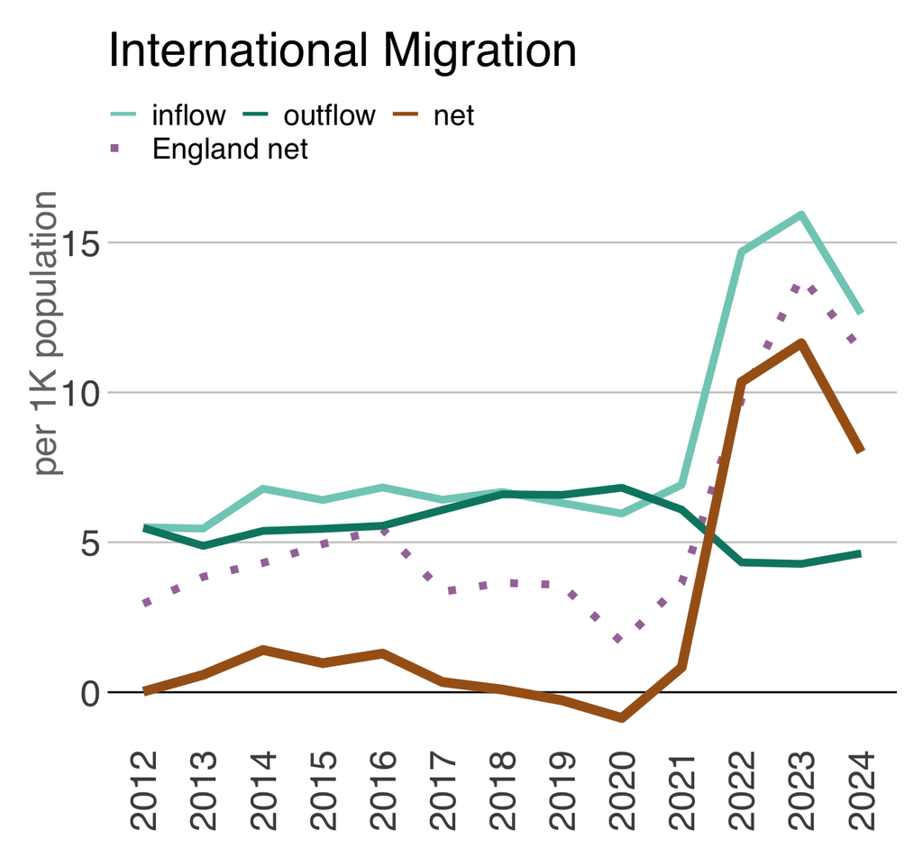